# Bill and Flipper Morphology of Palmer Archipelago Penguins

A Quarto report exploring body size relationships across three penguin species

Author

Yang An

Published

September 29, 2026

## Introduction

This report revisits the **`penguins`** dataset from the `palmerpenguins` package, which has already been used earlier in this course to explore flipper length and body mass. Here the focus shifts to a relationship we have *not* yet looked at closely: how **bill length** and **flipper length** relate to one another across the three species recorded at the Palmer Long-Term Ecological Research station in Antarctica – *Adelie*, *Chinstrap*, and *Gentoo* penguins.

The goals of this report are to:

- clean the data and remove any incomplete records,
- summarize body size by species and sex in a clean, readable table, and
- visualize the relationship between bill length and flipper length with a publication-quality figure.

## Data Preparation

Before summarizing or plotting anything, the raw `penguins` data are cleaned. Rows with missing measurements or unrecorded sex are dropped so that every summary statistic below is calculated from **complete cases only**. This keeps the table and the figure consistent with one another.

```r
# Drop any row with a missing value in the columns we actually use.
# This avoids NA-driven warnings later and keeps the table and the
# figure based on an identical set of individuals.
penguins_clean <- penguins |>
  drop_na(bill_length_mm, flipper_length_mm, body_mass_g, sex) |>
  mutate(
    species = as.factor(species),
    sex = as.factor(sex)
  )
```

## Summary Table

Table 1 below reports the **mean bill length**, **mean flipper length**, and sample size for each combination of species and sex. Grouping by both variables shows that, within every species, males tend to have slightly longer bills and flippers than females – a pattern worth keeping in mind before interpreting the scatter plot in the next section.

```r
penguin_summary <- penguins_clean |>
  group_by(species, sex) |>
  summarise(
    n = n(),
    mean_bill_length_mm = round(mean(bill_length_mm), 1),
    mean_flipper_length_mm = round(mean(flipper_length_mm), 1),
    .groups = "drop"
  )

# kableExtra turns the plain summary table into a styled HTML table:
# striped rows, a bolded header, and hover-highlighting make it easy
# to read on screen.
penguin_summary |>
  kbl(
    col.names = c("Species", "Sex", "n", "Mean Bill Length (mm)",
                  "Mean Flipper Length (mm)"),
    align = "c"
  ) |>
  kable_styling(
    bootstrap_options = c("striped", "hover", "condensed"),
    full_width = FALSE
  ) |>
  row_spec(0, bold = TRUE, color = "white", background = "#0072B2")
```

Table 1: Mean bill length and flipper length (mm) by species and sex, with sample sizes.

| Species | Sex | n | Mean Bill Length (mm) | Mean Flipper Length (mm) |
| --- | --- | --- | --- | --- |
| Adelie | female | 73 | 37.3 | 187.8 |
| Adelie | male | 73 | 40.4 | 192.4 |
| Chinstrap | female | 34 | 46.6 | 191.7 |
| Chinstrap | male | 34 | 51.1 | 199.9 |
| Gentoo | female | 58 | 45.6 | 212.7 |
| Gentoo | male | 61 | 49.5 | 221.5 |

## Visualizing the Relationship

Figure 1 shows bill length plotted against flipper length for every penguin in the cleaned dataset, colored by species. A few design choices were made deliberately, following best practices covered in lecture:

1. **Color-blind-safe palette.** The three species are distinguished using the Okabe-Ito palette (`#0072B2`, `#D55E00`, `#009E73`), which remains distinguishable for the most common forms of color vision deficiency.
2. **Linear trend lines per species**, added with `geom_smooth()`, make the *within-species* relationship easy to see even though the species overlap in places.
3. **Clear, fully-labeled axes and a legend title**, so the figure can stand alone without needing the surrounding text.

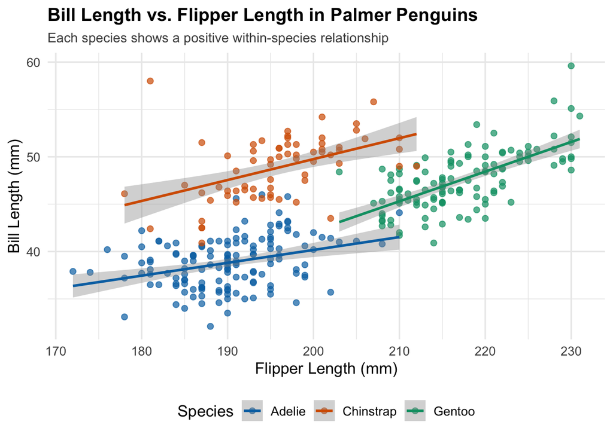

Figure 1: Bill length increases with flipper length within each penguin species. Points are individual penguins; lines are species-specific linear fits with 95% confidence ribbons.

```r
ggplot(penguins_clean, aes(x = flipper_length_mm, y = bill_length_mm,
                            color = species)) +
  geom_point(alpha = 0.7, size = 2) +
  geom_smooth(method = "lm", se = TRUE, linewidth = 1) +
  scale_color_manual(values = c(
    "Adelie" = "#0072B2",
    "Chinstrap" = "#D55E00",
    "Gentoo" = "#009E73"
  )) +
  labs(
    title = "Bill Length vs. Flipper Length in Palmer Penguins",
    subtitle = "Each species shows a positive within-species relationship",
    x = "Flipper Length (mm)",
    y = "Bill Length (mm)",
    color = "Species"
  ) +
  theme_minimal(base_size = 13) +
  theme(
    plot.title = element_text(face = "bold", size = 15),
    plot.subtitle = element_text(size = 11, color = "grey30"),
    legend.position = "bottom"
  )
```

Gentoo penguins (green) separate out clearly as the largest-bodied species, with the longest flippers and comparatively long bills, while Adelie and Chinstrap penguins overlap more in flipper length but remain distinguishable by bill length.